# Project Report

Gianluca Ikeda Ferretti & Carla Ebner

2025-07-01

# Introduction

In this project we aimed to reproduce some of the analyses from the publication “Antipsychotic-induced epigenomic reorganization in frontal cortex of individuals with schizophrenia”, Zhu et al. 2024 [1]. Although schizophrenia has long been considered a genetic disorder with high heritability [2], recent research suggests that this assumption may not be entirely accurate. Previous genome-wide association studies have even shown a quite low number of genetic regions associated with schizophrenia risk [3]. With twin studies, evidence was found for the high contribution of environmental factors to the development of schizophrenia [4]. Given the growing evidence for a substantial role of environmental influences, attention has increasingly shifted towards epigenetic mechanisms that may serve as mediators between environmental exposures and gene regulation in the brain. Gene expression is regulated by DNA accessibility within chromatin, which is modulated by epigenetic mechanisms such as DNA methylation and histone modifications. These modifications induce stable yet dynamic changes in gene expression without altering the DNA sequence and remain responsive throughout brain development and aging [5]. Based on this concept there is the assumption that epigenetic processes, mediate the effects of environmental factors on central nervous system gene activity and therefore contribute to the pathophysiology of mental illnesses, such as schizophrenia. Supporting this hypothesis, prior studies have identified differences in chromatin structure and accessibility between tissue samples from individuals with schizophrenia and healthy controls. Since previous research was mainly focused on alterations in DNA methylation, the focus of the paper we wanted to partially reproduce, was on changes in histone modifications. In this context, the publication “Antipsychotic-induced epigenomic reorganization in frontal cortex of individuals with schizophrenia” by Zhu et al. provides important insights into the role of histone modifications in schizophrenia. The persistent plasticity of histone modifications into adulthood allows environmental influences, including antipsychotic treatments, to alter access to genes and regulatory elements. To investigate these processes, Zhu et al. performed ChIP-seq analyses targeting two specific histone modifications: H3K27ac (histone H3 acetylation of lysine 27), marking active enhancers, and H3K4me3 (histone H3 trimethylation of lysine 4), marking active promoters. Both enhancers and promoters are known to be involved in the regulation of genes implicated in psychiatric conditions. For comparative analysis, frontal cortex samples were obtained from healthy controls, antipsychotic-free (AF) patients, and antipsychotic-treated (AT) patients. In a differential analysis to study alterations in histone modification patterns and gene activity between individuals with schizophrenia and healthy controls, thousands of differential enhancers, promoters, and differentially expressed genes (DEGs) were identified in both neuronal and non-neuronal cells. (2A/2B) To study epigenomic profiles in schizophrenia patients and controls, clusters of regulatory regions were identified that were significantly enriched for schizophrenia-associated differential histone marks and gene expression. These clusters were also functionally enriched for neuronal and synaptic genes, supporting the idea that schizophrenia affects specific, functionally coherent regions of the epigenome. (3A/B). After identifying AF-specific DEGs (genes dysregulated in antipsychotic-free schizophrenia but unchanged in treated patients) and performing an enrichment analysis, Zhu et al. could show that antipsychotic-free schizophrenia patients have distinct transcriptional and regulatory signatures enriched in synaptic signalling and autophagy pathways, which appear normalized in treated individuals, highlighting potential therapeutic mechanisms of antipsychotic drugs. (5G/H) We now wanted to reproduce these analyses and potentially compare our results to the findings in the original paper. Will our analyses result in the same outcome? How can we interpret our findings?

# Discussion

The first step in this analysis was to generate Summarised Experiment (SE) files starting from the processed BigWig files made accessible by the authors via Gene Expression Omnibus (GEO) under accession number GSE174407 (Script 1). We initially attempted to extract the signal by applying the function signal2Matrix from the epigenomic analysis package epiwraps, focusing only on promoter and enhancer regions annotated in ENCODE. This approach proved to be too demanding for the hardware we had available. When extracting only promoter signals from the dataset, besides requiring around 4 hours to complete, the resulting SE was 16Gb. This made it impossible to run any function on this file in R. Moreover, since the number of enhancers is much higher than promoters, the same code would run for much longer and required too much memory, leading to the automatic interruption of the running chunk. Hence, we decided to program-matically import from each BigWig file only the regions present in the selected BED file obtained with the AnnotationHub package and saved the mean signal for each region in a matrix. Additionally, we separately extracted from each file its metadata and together with the count matrix generated the final SE file. For both promoters and enhancers, we queried for annotations from the latest human reference genome (GRCh38), the same used by the authors to map their ChIP-seq data. For enhancers, the ENCODE Registry of candidate cis-Regulatory Elements (cCREs) classifies enhancer-like signatures in two subsets, proximal (pELS) and (dELS) [6]. We opted for pELS only because it contained 171292 entries, compared to the 755243 present in the distal subset, making analysis much less computationally demanding. In the publication, the authors only consider active enhancers those regions marked by H3K27ac that did not overlap with a promoter. Therefore, we checked whether the promoter and enhancer regions that we considered overlapped, but no match was identified. One final important aspect that we considered in both cases was the presence of all-zero and/or missing values rows. Since we are creating a matrix with rows corresponding to all genomic intervals present in the BED file, it is reasonable to think that some might not be present whatsoever in the data, and hence those rows were removed. With the manageable SE files, we proceeded to associate genes with the identified active promoters and enhancers. Promoters were linked to a gene when their genomic interval overlapped with the 500 bp region upstream a gene’s transcription start site, since proximal promoter regions are found 500 bps upstream the TSS [7]. A similar approach of overlapping was adopted in the original publication as well. An analogous procedure by overlapping genomic intervals was carried out to annotate enhancers with genes, but since pELS are described to be within 2kb of distance to a TSS we increased the enhancer regions width accordingly. If we were to use instead dELS the increase in width of the regions would be much greater, resulting in many more overlapping genes to each enhancer. In the original publication, annotation of enhancers was instead achieved by implementing published Hi-C data, and if no information was present then the enhancers were associated with their nearest genes. With the annotated SE files, we performed differential analysis to reproduce the results exhibited in figure 2. The limma package seen during lectures was applied to carry out the differential analysis used to generate volcano plots comparable to those in Figure 2C (Figure 1), while the original publication applied the R package DiffBind.

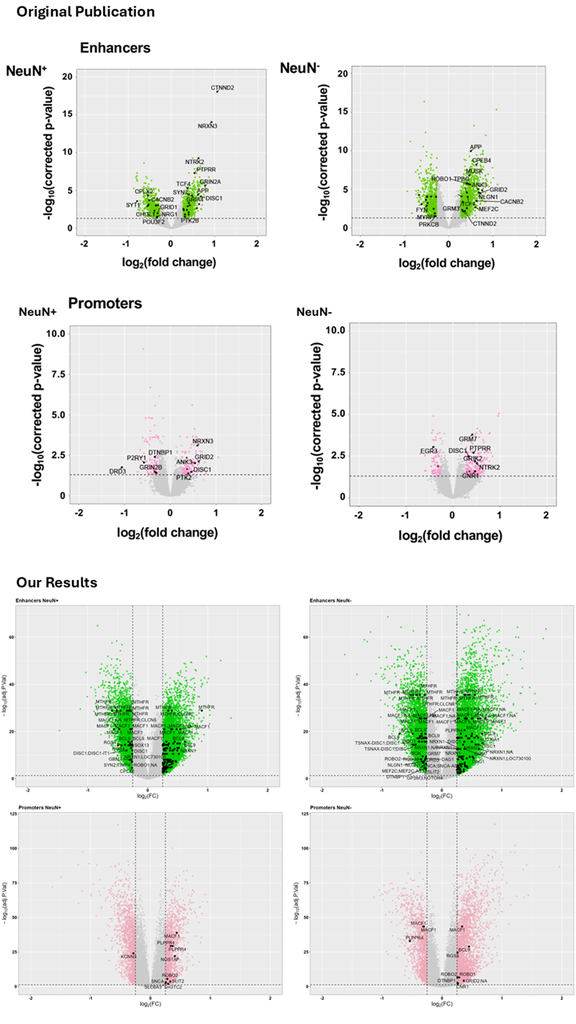

*Figure 1: Comparison between volcano plots to visualise differentially enriched regulatory regions in schizophrenia samples.*

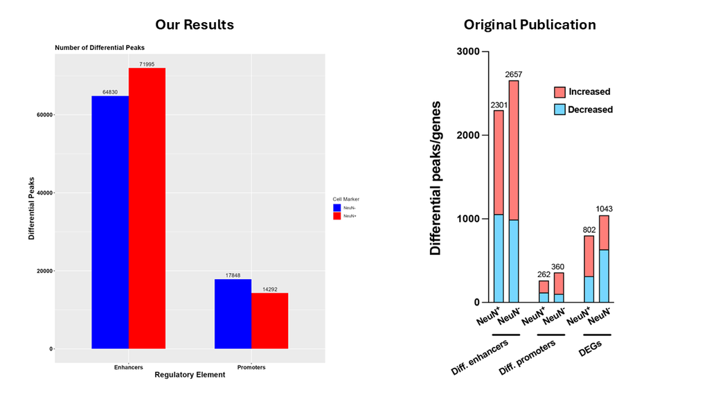

We identified around 30 times more differentially enriched enhancers compared to the original publication in both NeuN+ and NeuN- samples, while for promoters the increase is even greater at around 50 times. This means that a huge amount of regions were extracted from the processed data. We suppose that the explanation behind this enormous difference might primarily depend on the generation of the BigWig files. Most importantly, whether they were generated before or after filtering for low-enrichment peaks. To investigate this hypothesis, we decided to visualise the tracks of bigwig files using the epiwraps function plotSignalTracks from 2 BigWig files. If the files were generated before filtering one would expect a very noisy track. The resulting plotted tracks (Figure 3) clearly shows a noisy region with many low coverage peaks. Furthermore, some regions even have negative scores, which we have not encountered before.

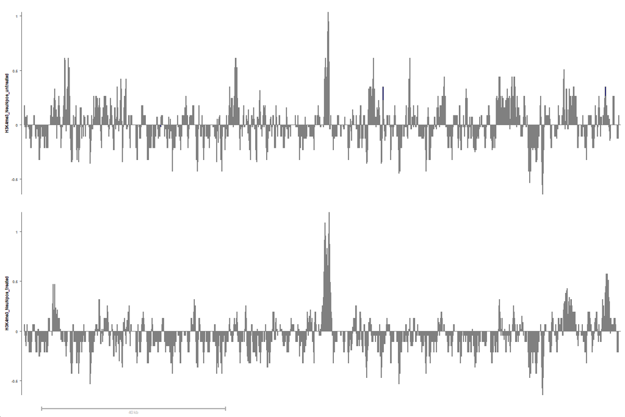

In conclusion, we state that the inflation of differentially enriched regulatory elements was caused by BigWig files containing noisy data. This led to most, if not all, regulatory regions investigated during signal extraction to present a signal, resulting in summarized experiment files containing an enormous number of peaks. This most likely impacted all the subsequent downstream analysis by contributing to the very low p values. Another aspect that might have influenced the statistical significance of certain peaks is that in their pipeline, the authors regressed sex, age at death, antemortem diagnosis and PMD variables. However, this information was not present in the processed data, hence they were still contributing to our linear model. Even though we realised that the initial data required a filtering step that we were not able to carry out, we decided to continue with further analysis and attempt to carry out an enrichment analysis. In Figure 3A of the paper the authors used an integrative method called EpiSig to combine epigenomic (H3K27ac and H3K4me3 histone marks) and transcriptomic data. They first identified genomic regions enriched for epigenomic signals and clustered them into 814 epigenetically similar groups. These were subsequently grouped into six broader clusters using the K-means clustering method. Due to the unavailability of the EpiSig tool in our setting, we adapted the clustering strategy slightly. Specifically, we performed two separate clustering analyses: one focused on enhancers and the other on promoters.

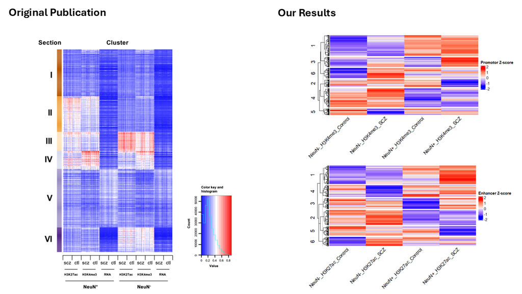

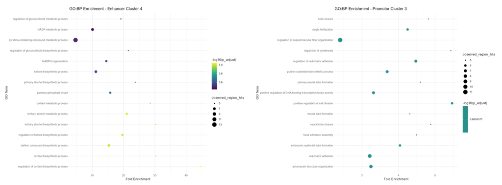

# Code

```r
knitr::opts_knit$set(root.dir = "C:/Users/gianl/Desktop/ETH/BiologyMsc/Spring Semester Material/BARGE/Project/data")
```

## Summarised Experiment Files

```r
suppressPackageStartupMessages({
  library(rtracklayer)
  library(GenomicRanges)
  library(AnnotationHub)
  library(SummarizedExperiment)
  library(tidyverse)
})
```

### Promoters

```r
# Set directory and list files for parsing
bw_files <- list.files("./GSE174407_RAW" ,pattern = "\\.bw$", full.names = TRUE)
bw_files_pro <- bw_files[grep(bw_files, pattern = "*_H3K4me3_*")]

pro_files <- as.character(bw_files_pro)
pro_filenames <- basename(pro_files)
pro_filenames <- as.character(pro_filenames)
```

```r
# Get promoter regions from ENCODE

ah <- AnnotationHub()
query_result <- query(ah, c("ENCODE", "promoter", "Homo sapiens", "hg38", "Gencode"))
query_result
```

```
## AnnotationHub with 1 record
## # snapshotDate(): 2024-10-28
## # names(): AH116729
## # $dataprovider: ENCODE
## # $species: Homo sapiens
## # $rdataclass: GRanges
## # $rdatadateadded: 2024-04-29
## # $title: ENCODE_PLS_regions
## # $description: A GRanges object containing regions of candidate cis-regulat...
## # $taxonomyid: 9606
## # $genome: hg38
## # $sourcetype: BED
## # $sourceurl: https://screen.encodeproject.org/
## # $sourcesize: NA
## # $tags: c("DnaseSeq", "ENCODE", "GenomicSequence", "H3K4me3",
## #   "Homo_sapiens", "peaks")
## # retrieve record with 'object[["AH116729"]]'
```

```r
promoters_gr <- ah[["AH116729"]]
```

```
## loading from cache
```

```r
# Store metadata promoter

sample_id <- str_extract(pro_filenames, "GSM\\d+")

condition <- case_when(
  str_detect(pro_filenames, "_SCZ_") ~ "SCZ",
  str_detect(pro_filenames, "_Control_") ~ "Control",
  TRUE ~ NA_character_
)

sample_number <- pro_filenames %>%
  str_extract("_(SCZ|Control)_\\d+") %>%
  str_extract("\\d+") %>%
  as.integer()

treatment_status <- case_when(
  str_detect(pro_filenames, "untreated") ~ "untreated",
  str_detect(pro_filenames, "treated") ~ "treated",
  TRUE ~ NA_character_
)

cell_marker <- str_extract(pro_filenames, "NeuN[+-]")
histone_mark <- str_extract(pro_filenames, "H3K4me3")
replicate <- str_extract(pro_filenames, "R[12]")

# Combine into tibble
metadata_promoter <- tibble(
  file = pro_files,
  filename = pro_filenames,
  sample_id = sample_id,
  condition = condition,
  sample_number = sample_number,
  treatment_status = treatment_status,
  cell_marker = cell_marker,
  histone_mark = histone_mark,
  replicate = replicate
)


print(metadata_promoter)
```

```
## # A tibble: 232 × 9
##    file  filename sample_id condition sample_number treatment_status cell_marker
##    <chr> <chr>    <chr>     <chr>             <int> <chr>            <chr>
##  1 ./GS… GSM5296… GSM52966… SCZ                   1 untreated        NeuN+
##  2 ./GS… GSM5296… GSM52966… SCZ                   1 untreated        NeuN+
##  3 ./GS… GSM5296… GSM52966… SCZ                   2 untreated        NeuN+
##  4 ./GS… GSM5296… GSM52966… SCZ                   2 untreated        NeuN+
##  5 ./GS… GSM5296… GSM52966… SCZ                   3 untreated        NeuN+
##  6 ./GS… GSM5296… GSM52966… SCZ                   3 untreated        NeuN+
##  7 ./GS… GSM5296… GSM52966… SCZ                   4 untreated        NeuN+
##  8 ./GS… GSM5296… GSM52966… SCZ                   4 untreated        NeuN+
##  9 ./GS… GSM5296… GSM52966… SCZ                   5 untreated        NeuN+
## 10 ./GS… GSM5296… GSM52966… SCZ                   5 untreated        NeuN+
## # ℹ 222 more rows
## # ℹ 2 more variables: histone_mark <chr>, replicate <chr>
```

This is the code that we tried to apply using with signal2Matrix epiwraps function

sample_ids <- str_extract(basename(bw_files_pro), “GSM\d+”)

names(bw_files_pro) <- sample_ids

stopifnot(!any(is.na(names(bw_files_pro))))

se_promoter <- epiwraps::signal2Matrix( filepaths = bw_files_pro, regions = promoters_gr )

colData(se_promoter) <- DataFrame(metadata_promoter)

saveRDS(se_promoter, file = “sumExp_promoter.rds”)

```r
# quantification function
quantify_bw <- function(bw_file, regions){
  cov <- import(bw_file, which = regions, as = "NumericList")
  sapply(cov, mean, na.rm = TRUE)
}

# create matrix
count_matrix_promoter <- matrix(NA, nrow = length(promoters_gr), ncol = nrow(metadata_promoter))
rownames(count_matrix_promoter) <- paste0(seqnames(promoters_gr), ":", start(promoters_gr), "-", end(promoters_gr))
colnames(count_matrix_promoter) <- metadata_promoter$sample_id

# fill matrix
for (i in seq_len(nrow(metadata_promoter))){
  cat("Processing:", metadata_promoter$file[i], "\n")
  count_matrix_promoter[, i] <- quantify_bw(metadata_promoter$file[i], promoters_gr)
}
```

[output not shown]

[output cut: 177 more lines]

```
## Processing: ./GSE174407_RAW/GSM5297136_Control_22_NeuN-_H3K4me3_R2.bw
## Processing: ./GSE174407_RAW/GSM5297137_Control_23_NeuN-_H3K4me3_R1.bw
## Processing: ./GSE174407_RAW/GSM5297138_Control_23_NeuN-_H3K4me3_R2.bw
## Processing: ./GSE174407_RAW/GSM5297139_Control_24_NeuN-_H3K4me3_R1.bw
## Processing: ./GSE174407_RAW/GSM5297141_Control_24_NeuN-_H3K4me3_R2.bw
## Processing: ./GSE174407_RAW/GSM5297142_Control_25_NeuN-_H3K4me3_R1.bw
## Processing: ./GSE174407_RAW/GSM5297144_Control_25_NeuN-_H3K4me3_R2.bw
## Processing: ./GSE174407_RAW/GSM5297145_Control_26_NeuN-_H3K4me3_R1.bw
## Processing: ./GSE174407_RAW/GSM5297147_Control_26_NeuN-_H3K4me3_R2.bw
## Processing: ./GSE174407_RAW/GSM5297148_Control_27_NeuN-_H3K4me3_R1.bw
## Processing: ./GSE174407_RAW/GSM5297150_Control_27_NeuN-_H3K4me3_R2.bw
## Processing: ./GSE174407_RAW/GSM5297151_Control_28_NeuN-_H3K4me3_R1.bw
## Processing: ./GSE174407_RAW/GSM5297153_Control_28_NeuN-_H3K4me3_R2.bw
## Processing: ./GSE174407_RAW/GSM5297155_Control_29_NeuN-_H3K4me3_R1.bw
## Processing: ./GSE174407_RAW/GSM5297156_Control_29_NeuN-_H3K4me3_R2.bw
```

```r
any(rowSums(count_matrix_promoter[]) == 0) # No rows are equal zero, so all promoter regions present some signal.
```

```
## [1] FALSE
```

```r
any(is.na(count_matrix_promoter)) # No NAs
```

```
## [1] FALSE
```

```r
se <- SummarizedExperiment(
  assays = list(signal = count_matrix_promoter),
  rowRanges = promoters_gr,
  colData = as.data.frame(metadata_promoter)
)

saveRDS(se, file = "sumExp_promoter.rds")
```

### Enhancers

```r
# Select enhancer regions

query_result2 <- query(ah, c("ENCODE", "enhancer", "Homo sapiens", "hg38", "Gencode"))
query_result2
```

```
## AnnotationHub with 2 records
## # snapshotDate(): 2024-10-28
## # $dataprovider: ENCODE
## # $species: Homo sapiens
## # $rdataclass: GRanges
## # additional mcols(): taxonomyid, genome, description,
## #   coordinate_1_based, maintainer, rdatadateadded, preparerclass, tags,
## #   rdatapath, sourceurl, sourcetype
## # retrieve records with, e.g., 'object[["AH116727"]]'
##
##              title
##   AH116727 | ENCODE_dELS_regions
##   AH116728 | ENCODE_pELS_regions
```

```r
enhancers_gr <- ah[["AH116728"]]
```

```
## loading from cache
```

```r
# Prepare list for parsing

bw_files_enh <- bw_files[grep(bw_files, pattern = "*_H3K27ac_*")]

enh_files <- as.character(bw_files_enh)
enh_filenames <- basename(enh_files)
enh_filenames <- as.character(enh_filenames)
```

```r
# Store metadata enhancers

sample_id_e <- str_extract(enh_filenames, pattern = "GSM\\d+")

condition_e <- case_when(
  str_detect(enh_filenames ,"_SCZ_") ~ "SCZ",
  str_detect(enh_filenames, "_Control_") ~ "Control",
  TRUE ~ NA_character_
)

sample_number_e <- enh_filenames %>%
  str_extract("_(SCZ|Control)_\\d+") %>%
  str_extract("\\d+") %>%
  as.integer()

treatment_status_e <- case_when(
  str_detect(enh_filenames, "untreated") ~ "untreated",
  str_detect(enh_filenames, "treated") ~ "treated",
  TRUE ~ NA_character_
)

cell_marker_e <- str_extract(enh_filenames, "NeuN[+-]")
histone_mark_e <- str_extract(enh_filenames, "H3K27ac")
replicate_e <- str_detect(enh_filenames, "R[12]")

metadata_enhancer <- tibble(
  file = enh_files,
  filename = enh_filenames,
  sample_id = sample_id_e,
  condition = condition_e,
  sample_number = sample_number_e,
  treatment_status = treatment_status_e,
  cell_marker = cell_marker_e,
  histone_mark = histone_mark_e,
  replicate = replicate_e
)

print(metadata_enhancer)
```

```
## # A tibble: 232 × 9
##    file  filename sample_id condition sample_number treatment_status cell_marker
##    <chr> <chr>    <chr>     <chr>             <int> <chr>            <chr>
##  1 ./GS… GSM5296… GSM52968… SCZ                   1 untreated        NeuN+
##  2 ./GS… GSM5296… GSM52968… SCZ                   1 untreated        NeuN+
##  3 ./GS… GSM5296… GSM52968… SCZ                   2 untreated        NeuN+
##  4 ./GS… GSM5296… GSM52968… SCZ                   2 untreated        NeuN+
##  5 ./GS… GSM5296… GSM52968… SCZ                   3 untreated        NeuN+
##  6 ./GS… GSM5296… GSM52968… SCZ                   3 untreated        NeuN+
##  7 ./GS… GSM5296… GSM52968… SCZ                   4 untreated        NeuN+
##  8 ./GS… GSM5296… GSM52968… SCZ                   4 untreated        NeuN+
##  9 ./GS… GSM5296… GSM52968… SCZ                   5 untreated        NeuN+
## 10 ./GS… GSM5296… GSM52968… SCZ                   5 untreated        NeuN+
## # ℹ 222 more rows
## # ℹ 2 more variables: histone_mark <chr>, replicate <lgl>
```

Attempt with signal2Matrix

sample_ids_e <- str_extract(basename(bw_files_enh), “GSM\d+”)

names(bw_files_enh) <- sample_ids_e

stopifnot(!any(is.na(names(bw_files_enh))))

We also attempted to split regions into chunks so that the memory will not be occupied all at once, but it was not sufficient and it would still lead to an error.

gr_chunks <- split(enhancers_gr, ceiling(seq_along(enhancers_gr) / 10000))

se_list <- vector(“list”, length(gr_chunks))

for (i in seq_along(gr_chunks)) { message(“Processing chunk”, i) se_list[[i]] <- epiwraps::signal2Matrix( filepaths = bw_files_enh, regions = gr_chunks[[i]] SerialParam() ) }

se_e <- readRDS(“SumExp_Enh.rds”)

```r
# Enhancer signal quantification from BW, SummarizedExperiment and export

# create matrix
count_matrix_enhancer <- matrix(NA, nrow = length(enhancers_gr), ncol = nrow(metadata_enhancer))
rownames(count_matrix_enhancer) <- paste0(seqnames(enhancers_gr), ":", start(enhancers_gr), "-", end(enhancers_gr))
colnames(count_matrix_enhancer) <- metadata_enhancer$sample_id

# See if any of the selected enhancers overlap with promoters as they did in the paper
hits <- findOverlaps(enhancers_gr, promoters_gr)
hits # No overlaps
```

```
## Hits object with 0 hits and 0 metadata columns:
##    queryHits subjectHits
##    <integer>   <integer>
##   -------
##   queryLength: 171292 / subjectLength: 40734
```

```r
# loop thorugh bigwig files to fill matrix with count
for (i in seq_len(nrow(metadata_enhancer))){
  cat("Processing:", metadata_enhancer$file[i], "\n")
  count_matrix_enhancer[,i] <- quantify_bw(metadata_enhancer$file[i], enhancers_gr)
}
```

[output not shown]

[output cut: 177 more lines]

```
## Processing: ./GSE174407_RAW/GSM5297323_Control_22_NeuN-_H3K27ac_R2.bw
## Processing: ./GSE174407_RAW/GSM5297324_Control_23_NeuN-_H3K27ac_R1.bw
## Processing: ./GSE174407_RAW/GSM5297326_Control_23_NeuN-_H3K27ac_R2.bw
## Processing: ./GSE174407_RAW/GSM5297328_Control_24_NeuN-_H3K27ac_R1.bw
## Processing: ./GSE174407_RAW/GSM5297329_Control_24_NeuN-_H3K27ac_R2.bw
## Processing: ./GSE174407_RAW/GSM5297331_Control_25_NeuN-_H3K27ac_R1.bw
## Processing: ./GSE174407_RAW/GSM5297332_Control_25_NeuN-_H3K27ac_R2.bw
## Processing: ./GSE174407_RAW/GSM5297334_Control_26_NeuN-_H3K27ac_R1.bw
## Processing: ./GSE174407_RAW/GSM5297335_Control_26_NeuN-_H3K27ac_R2.bw
## Processing: ./GSE174407_RAW/GSM5297337_Control_27_NeuN-_H3K27ac_R1.bw
## Processing: ./GSE174407_RAW/GSM5297338_Control_27_NeuN-_H3K27ac_R2.bw
## Processing: ./GSE174407_RAW/GSM5297340_Control_28_NeuN-_H3K27ac_R1.bw
## Processing: ./GSE174407_RAW/GSM5297341_Control_28_NeuN-_H3K27ac_R2.bw
## Processing: ./GSE174407_RAW/GSM5297343_Control_29_NeuN-_H3K27ac_R1.bw
## Processing: ./GSE174407_RAW/GSM5297345_Control_29_NeuN-_H3K27ac_R2.bw
```

```r
any(rowSums(count_matrix_enhancer[]) == 0) # some rows are equal zero
```

```
## [1] TRUE
```

```r
any(is.na(count_matrix_enhancer)) # No NAs
```

```
## [1] FALSE
```

```r
# Remove rows where sum is zero
filtered_matrix_enhancer <- count_matrix_enhancer[rowSums(count_matrix_enhancer[])>0,]

filtered_enhancers_gr <-enhancers_gr[rowSums(count_matrix_enhancer[])>0]

any(rowSums(filtered_matrix_enhancer[]) == 0) # no more rows with all zero values
```

```
## [1] FALSE
```

```r
# generate a SummarizedExperiment
enh_se <- SummarizedExperiment(
  assays = list(signal = filtered_matrix_enhancer),
  rowRanges = filtered_enhancers_gr,
  colData = as.data.frame(metadata_enhancer)
)

saveRDS(enh_se, file = "sumExp_Enh.rds")
```

## Regulatory Elements Annotation

```r
suppressPackageStartupMessages({
  library(GenomicRanges)
  library(AnnotationHub)
})
```

```r
# Promoter Associated genes
se_p <- readRDS("sumExp_promoter.rds")

promoters_gr <- rowRanges(se_p)

# authors used gencode annotation v29 on hg38
ah <- AnnotationHub()
q <- query(ah, c("gencode", "gene", "GRCh38"))
genes <- ah[["AH75174"]]
```

```
## loading from cache
```

```r
tss_genes <- resize(genes, width = 1, fix = "start")
tss_region <- promoters(tss_genes, upstream = 500)

# Check genome metadata
genome(promoters_gr) # empty
```

```
##  chr1  chr2  chr3  chr4  chr5  chr6  chr7  chr8  chr9 chr10 chr11 chr12 chr13
##    NA    NA    NA    NA    NA    NA    NA    NA    NA    NA    NA    NA    NA
## chr14 chr15 chr16 chr17 chr18 chr19 chr20 chr21 chr22  chrX  chrY
##    NA    NA    NA    NA    NA    NA    NA    NA    NA    NA    NA
```

```r
genome(genes)
```

```
##   chr1   chr2   chr3   chr4   chr5   chr6   chr7   chr8   chr9  chr10  chr11
## "hg38" "hg38" "hg38" "hg38" "hg38" "hg38" "hg38" "hg38" "hg38" "hg38" "hg38"
##  chr12  chr13  chr14  chr15  chr16  chr17  chr18  chr19  chr20  chr21  chr22
## "hg38" "hg38" "hg38" "hg38" "hg38" "hg38" "hg38" "hg38" "hg38" "hg38" "hg38"
##   chrX   chrY   chrM
## "hg38" "hg38" "hg38"
```

```r
genome(promoters_gr) <- genome(genes)

hits <- findOverlaps(promoters_gr, tss_region)
prom_index <- queryHits(hits)
gene_names <- mcols(genes)$Gene[subjectHits(hits)]

# Collapse gene names for promoters with multiple hits
collapsed_names <- tapply(gene_names, prom_index, function(x) paste(unique(x), collapse = ";"))

# Convert to a full-length character vector
all_gene_names <- rep(NA_character_, length(promoters_gr)) # create vector
all_gene_names[as.integer(names(collapsed_names))] <- collapsed_names # fill vector

# Add column for gene names to Summarised Experiment

rowData(se_p)$gene <- all_gene_names

head(rowData(se_p)$gene)
```

```
## [1] "NA"                     "NA"                     "FAM87B"
## [4] "LINC00115;LOC101928626" NA                       "NA"
```

```r
# save SE
saveRDS(se_p, "SumExp_pro_with_genes.rds")
```

```r
# Enhancer associated genes
se_e <- readRDS("sumExp_Enh.rds")

enhancer_gr <- rowRanges(se_e)

enh_regions <- resize(enhancer_gr, width = width(enhancer_gr)+ 2000, fix = "center")

# Make sure that my regions and the genes have the same metadata again
genome(enh_regions) <- genome(genes)

# Find overlapping genes
hits_enh <- findOverlaps(enh_regions, genes)
enh_index <- queryHits(hits_enh)
enh_gene_names <- mcols(genes)$Gene[subjectHits(hits_enh)]

collapsed_enh_names <- tapply(enh_gene_names, enh_index, function(x) paste(unique(x), collapse = ";"))

all_gene_names2 <- rep(NA_character_, length(enhancer_gr))
all_gene_names2[as.integer(names(collapsed_enh_names))] <- collapsed_enh_names

rowData(se_e)$gene <- all_gene_names2

head(rowData(se_e)$gene)
```

```
## [1] "LOC101928626;NA"        "LOC101928626;NA"        "LOC101928626;NA"
## [4] "LOC101928626;NA;FAM87B" "LOC101928626;NA;FAM87B" "LOC101928626;FAM87B"
```

```r
# Save results
saveRDS(se_e, "SumExp_enh_with_genes.rds")
```

## Differential Analysis¨

### Promoters

```r
suppressPackageStartupMessages({
  library(limma)
  library(SummarizedExperiment)
  library(ggplot2)
  library(ggrepel)
})
```

```r
se_p <- readRDS("SumExp_pro_with_genes.rds")
```

```r
# Differential analysis NeuN+

# Separate NeuN+ and NeuN- and also control

metadata <- colData(se_p)
metadata$cell_marker <- factor(metadata$cell_marker)
metadata$treatment_status <- factor(metadata$treatment_status)

# Filter NeuN+ and SCZ
idx_neun_pos_scz_unt <- which(
  metadata$cell_marker == "NeuN+" &
  metadata$condition == "SCZ"
)

# Filter NeuN+ Control samples
idx_neun_pos_control <- which(
  metadata$cell_marker == "NeuN+" &
  metadata$condition == "Control"
)

se_neun_pos_combined <- se_p[, c(idx_neun_pos_scz_unt, idx_neun_pos_control)]

# Diff Analysis

# Trasform in log for limma
log_matrix_pos <- log2(assay(se_neun_pos_combined)+1)

# compare SCZ against control
md_pos <- colData(se_neun_pos_combined)

md_pos$condition <- relevel(factor(md_pos$condition), "Control")

mm_pos <- model.matrix(~ condition, data = md_pos)

# linear model

fit_pos <- limma::eBayes(limma::lmFit(object = log_matrix_pos, design = mm_pos))
```

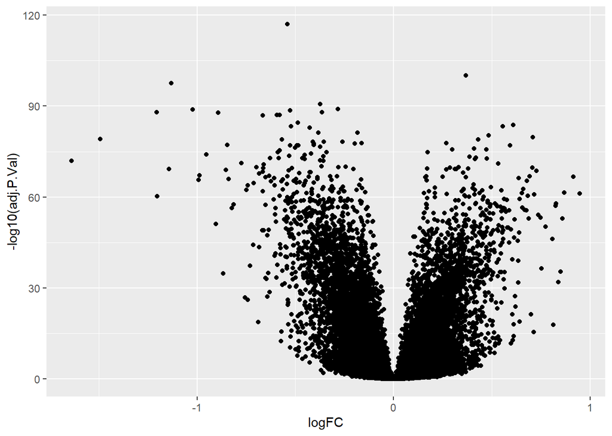

```r
res_pos <- as.data.frame(limma::topTable(fit_pos, coef = "conditionSCZ", number = Inf))

saveRDS(res_pos,"DF_DA_pro_NeuN+.rds")

ggplot(res_pos, aes(logFC, -log10(adj.P.Val)))+geom_point()
```

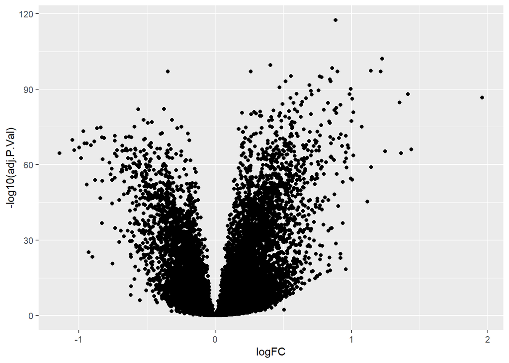

```r
# Differential Analysis NeuN-

# Filter NeuN- and SCZ
idx_neun_neg_scz_unt <- which(
  metadata$cell_marker == "NeuN-" &
  metadata$condition == "SCZ"
)

# Filter NeuN+ Control samples
idx_neun_neg_control <- which(
  metadata$cell_marker == "NeuN-" &
  metadata$condition == "Control"
)

se_neun_neg_combined <- se_p[, c(idx_neun_neg_scz_unt, idx_neun_neg_control)]

# Diff Analysis

# Trasform in log for limma
log_matrix_neg <- log2(assay(se_neun_neg_combined)+1)

# compare SCZ against control
md_neg <- colData(se_neun_neg_combined)

md_neg$condition <- relevel(factor(md_neg$condition), "Control")

mm_neg <- model.matrix(~ condition, data = md_neg)

# linear model

fit_neg <- limma::eBayes(limma::lmFit(object = log_matrix_neg, design = mm_neg))
res_neg <- as.data.frame(limma::topTable(fit_neg, coef = "conditionSCZ", number = Inf))

saveRDS(res_neg, "DF_DA_pro_NeuN-.rds")

ggplot(res_neg, aes(logFC, -log10(adj.P.Val)))+geom_point()
```

```r
# Volcano plots with matching genes

# This is the list of genes provided by the authors in their github page
candidate_SCZ_genes = c('AKT1','APOE',"BDNF","CHRNA7","COMT","DAO","DAOA","DISC1","DRD2","DRD3",
                    "DRD4","DTNBP1","GRM3","HTR2A","KCNN3","MTHFR","NOTCH4","NRG1","PPP3CC,PRODH",
                    "RGS4","SLC6A3","SLC6A4","TNF","ZDHHC8","CTNND2","NRXN3","PTPRR","SLIT2","ANK3",
                    "APP","PTK2","FYN","ROBO1","PLPPR4","GRIK2","CDK5R1","GRIA2","GRID2","GRIN3A",
                    "GRIN2B","GRIN2A","GRIA3","GRIA4","TIAM1","GRIA1","GRIN1","CLN3","GRID1","CPEB4",
                    "PTK2B","MEF2C","MUSK","PPP1R9A","NRXN1","TPBG","LRRTM3","ROBO2","DAG1","FA2H",
                    "DICER1","NTRK2","SH3TC2","NDRG1","ARHGEF10","POU3F2","SOD1","ILK","CDK5","CPLX2",
                    "SNCA","SLC30A1","NLGN1","P2RY1","SYT1","CNR1","CACNB2","PRKCB","EBF1","CHD9",
                    "PCK1","DRD5","TCEB2","CHRNA2","CHRNA6","FGF17","SOX9","GSN","PLP1","CD9",
                    "BOK","ASPA","SOX8","OLIG2","OLIG1","KCNJ10","CNP","SOX13","MYRF","GRM5",
                    "GRM7","GRM8","EGR3","NTNG2","DVL2","DLG4","MACF1","FZD4",'SHANK3','VIPR2',
                    'SLC1A1','RBM12',"APOL2","SCZD12","CHI3L1","DISC2","SYN2","SCZD1","SCZD3","SCZD5",
                    "SCZD6","SCZD11","SCZD2","SCZD7","SCZD8","RTN4R","APOL4",'G72','PRODH2','ZDHHC8',
                    'TAAR6','NOS1AP','TPH1','AHI1','RELN','TRKA','ZNF804','TCF','NRGRN','BCL9','NRGN',
                    'TCF4','ARVCF','CNNM2','CACNA1C')


res_pos$gene <- rowData(se_neun_pos_combined)$gene

res_neg$gene <- rowData(se_neun_neg_combined)$gene

head(res_pos$gene)
```

```
## [1] "NA"                     "NA"                     "FAM87B"
## [4] "LINC00115;LOC101928626" NA                       "NA"
```

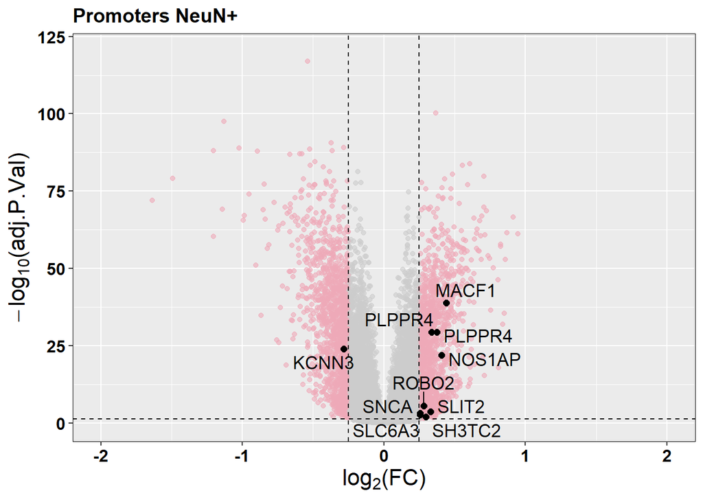

```r
logFC_thresh <- 0.25
pval_thresh <- 0.05


# NeuN+ Volcano Plot

res_pos$significant <- res_pos$adj.P.Val < pval_thresh & abs(res_pos$logFC) > logFC_thresh # label significant points

res_pos$scz_gene <- sapply(res_pos$gene, function(x){
  if (is.na(x)) return(FALSE)
  any(strsplit(x, ";")[[1]] %in% candidate_SCZ_genes)
}) # label points that correspond to SCZ genes

res_pos$plot_col <- ifelse(!res_pos$significant, "not_significant",
                           ifelse(res_pos$scz_gene, "scz_gene", "significant")) # create column with label information

res_pos$plot_col <- factor(res_pos$plot_col, levels = c("not_significant", "significant", "scz_gene")) # set labels as factor

base_points_pos <- subset(res_pos, !(scz_gene & significant))
scz_points_pos <- subset(res_pos, scz_gene & significant)

plot1 <- ggplot()+
  geom_point(data = base_points_pos, aes(x= logFC, y = -log10(adj.P.Val), color = significant), alpha = 0.6)+
  geom_point(data = scz_points_pos, aes(x= logFC, y = -log10(adj.P.Val)), color = "black", size = 2)+
  scale_color_manual(values = c("TRUE" = "pink2", "FALSE" = "grey80"))+
  geom_text_repel(
    data = scz_points_pos,
    aes(x = logFC, y = -log10(adj.P.Val), label = gene),
    size = 4.5,
    max.overlaps = 20)+
  geom_vline(xintercept = c(-logFC_thresh, logFC_thresh), linetype = "dashed")+
  geom_hline(yintercept = -log10(pval_thresh), linetype = "dashed")+
  xlim(-2,2)+
  ylim(0,120)+
  theme(legend.position = "none")+
  labs(
    title = "Promoters NeuN+",
    x = expression(log[2]*"(FC)"),
    y = expression(-log[10]*"(adj.P.Val)"),
    size = 1
  )+
  theme(
    plot.title = element_text(size=14, face= "bold", colour= "black" ),
    axis.title.x = element_text(size=16, face="bold", colour = "black"),
    axis.title.y = element_text(size=16, face="bold", colour = "black"),
    axis.text.x = element_text(size=12, face="bold", colour = "black"),
    axis.text.y = element_text(size=12, face="bold", colour = "black"), # bold
    strip.text.x = element_text(size = 10, face="bold", colour = "black" ),
    strip.text.y = element_text(size = 10, face="bold", colour = "black"),
    panel.border = element_rect(colour = "black", fill=NA, size=0.3)
  )
print(plot1)
```

```r
ggsave("C:/Users/gianl/Desktop/ETH/BiologyMsc/Spring Semester Material/BARGE/Project/data/DF_plot_pro_NeuNpos.png",
       plot = plot1,
       width = 11,
       height = 8,
       dpi = 150)
```

### Enhancers

```r
suppressPackageStartupMessages({
  library(limma)
  library(SummarizedExperiment)
  library(ggplot2)
  library(ggrepel)
})
```

```r
se_e <- readRDS("SumExp_enh_with_genes.rds")
```

```r
# Differential Analysis NeuN+

metadata <- colData(se_e)
metadata$cell_marker <- factor(metadata$cell_marker)
metadata$treatment_status <- factor(metadata$treatment_status)

# Filter NeuN+ and SCZ untreated samples
idx_enh_neun_pos_scz_unt <- which(
  metadata$cell_marker == "NeuN+" &
  metadata$condition == "SCZ"
)

# Filter NeuN+ Control samples
idx_enh_neun_pos_control <- which(
  metadata$cell_marker == "NeuN+" &
  metadata$condition == "Control"
)

se_enh_neun_pos_combined <- se_e[, c(idx_enh_neun_pos_scz_unt, idx_enh_neun_pos_control)]

# Diff Analysis

log_enh_matrix_pos <- log2(assay(se_enh_neun_pos_combined)+1)

md_enh_pos <- colData(se_enh_neun_pos_combined)

md_enh_pos$condition <- relevel(factor(md_enh_pos$condition), "Control")

mm_enh_pos <- model.matrix(~ condition, data = md_enh_pos)

# linear model

fit_enh_pos <- limma::eBayes(limma::lmFit(object = log_enh_matrix_pos, design = mm_enh_pos))
```

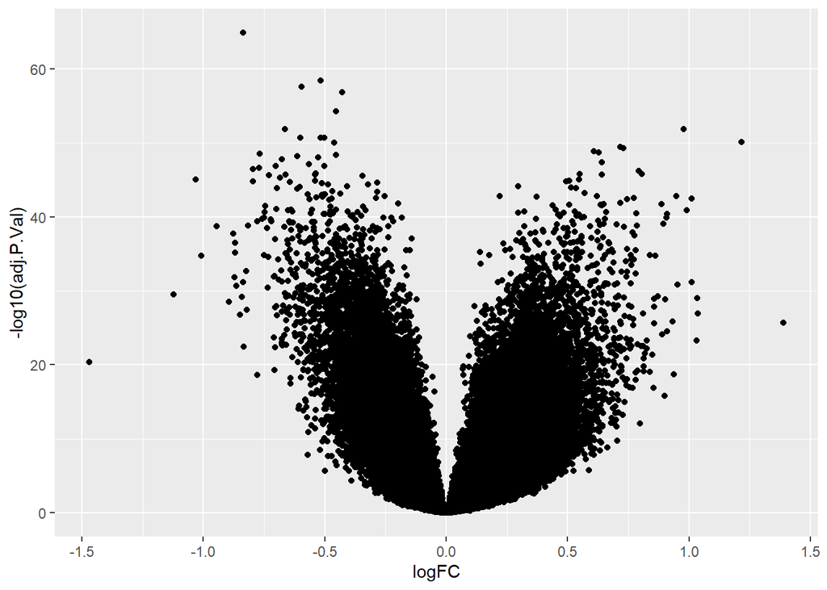

```r
res_enh_pos <- as.data.frame(limma::topTable(fit_enh_pos, coef = "conditionSCZ", number = Inf))

saveRDS(res_enh_pos, "DF_DA_enh_NeuN+.rds")

ggplot(res_enh_pos, aes(logFC, -log10(adj.P.Val)))+geom_point()
```

```r
# Differential Analysis NeuN-

# Filter NeuN- and SCZ untreated samples
idx_enh_neun_neg_scz_unt <- which(
  metadata$cell_marker == "NeuN-" &
  metadata$condition == "SCZ"
)

# Filter NeuN- Control samples
idx_enh_neun_neg_control <- which(
  metadata$cell_marker == "NeuN-" &
  metadata$condition == "Control"
)

se_enh_neun_neg_combined <- se_e[, c(idx_enh_neun_neg_scz_unt, idx_enh_neun_neg_control)]

# Diff Anal

log_enh_matrix_neg <- log2(assay(se_enh_neun_neg_combined)+1)
```

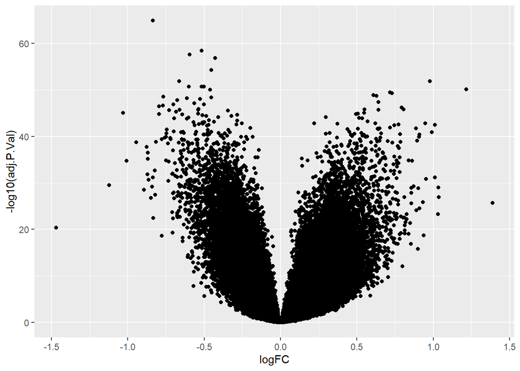

```r
md_enh_neg <- colData(se_enh_neun_neg_combined)

md_enh_neg$condition <- relevel(factor(md_enh_neg$condition), "Control")

mm_enh_neg <- model.matrix(~ condition, data = md_enh_neg)

# linear model

fit_enh_neg <- limma::eBayes(limma::lmFit(object = log_enh_matrix_neg, design = mm_enh_pos))
res_enh_neg <- as.data.frame(limma::topTable(fit_enh_neg, coef = "conditionSCZ", number = Inf))

saveRDS(res_enh_neg, "DF_DA_enh_NeuN-.rds")

ggplot(res_enh_pos, aes(logFC, -log10(adj.P.Val)))+geom_point()
```

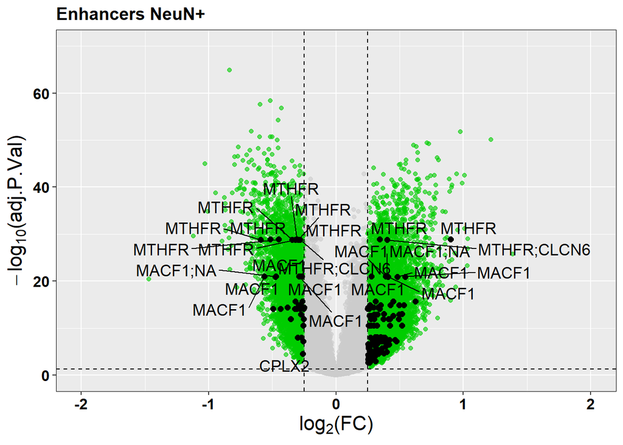

```r
# Volcano Plot with matching gene names

# This is the list of genes provided by the authors in their github page
candidate_SCZ_genes = c('AKT1','APOE',"BDNF","CHRNA7","COMT","DAO","DAOA","DISC1","DRD2","DRD3",
                    "DRD4","DTNBP1","GRM3","HTR2A","KCNN3","MTHFR","NOTCH4","NRG1","PPP3CC,PRODH",
                    "RGS4","SLC6A3","SLC6A4","TNF","ZDHHC8","CTNND2","NRXN3","PTPRR","SLIT2","ANK3",
                    "APP","PTK2","FYN","ROBO1","PLPPR4","GRIK2","CDK5R1","GRIA2","GRID2","GRIN3A",
                    "GRIN2B","GRIN2A","GRIA3","GRIA4","TIAM1","GRIA1","GRIN1","CLN3","GRID1","CPEB4",
                    "PTK2B","MEF2C","MUSK","PPP1R9A","NRXN1","TPBG","LRRTM3","ROBO2","DAG1","FA2H",
                    "DICER1","NTRK2","SH3TC2","NDRG1","ARHGEF10","POU3F2","SOD1","ILK","CDK5","CPLX2",
                    "SNCA","SLC30A1","NLGN1","P2RY1","SYT1","CNR1","CACNB2","PRKCB","EBF1","CHD9",
                    "PCK1","DRD5","TCEB2","CHRNA2","CHRNA6","FGF17","SOX9","GSN","PLP1","CD9",
                    "BOK","ASPA","SOX8","OLIG2","OLIG1","KCNJ10","CNP","SOX13","MYRF","GRM5",
                    "GRM7","GRM8","EGR3","NTNG2","DVL2","DLG4","MACF1","FZD4",'SHANK3','VIPR2',
                    'SLC1A1','RBM12',"APOL2","SCZD12","CHI3L1","DISC2","SYN2","SCZD1","SCZD3","SCZD5",
                    "SCZD6","SCZD11","SCZD2","SCZD7","SCZD8","RTN4R","APOL4",'G72','PRODH2','ZDHHC8',
                    'TAAR6','NOS1AP','TPH1','AHI1','RELN','TRKA','ZNF804','TCF','NRGRN','BCL9','NRGN',
                    'TCF4','ARVCF','CNNM2','CACNA1C')


res_enh_pos$gene <- rowData(se_enh_neun_pos_combined)$gene

res_enh_neg$gene <- rowData(se_enh_neun_neg_combined)$gene


logFC_thresh <- 0.25
pval_thresh <- 0.05


# NeuN+ Volcano Plot

res_enh_pos$significant <- res_enh_pos$adj.P.Val < pval_thresh & abs(res_enh_pos$logFC) > logFC_thresh # label significant points

res_enh_pos$scz_gene <- sapply(res_enh_pos$gene, function(x){
  if (is.na(x)) return(FALSE)
  any(strsplit(x, ";")[[1]] %in% candidate_SCZ_genes)
}) # label points that correspond to SCZ genes

res_enh_pos$plot_col <- ifelse(!res_enh_pos$significant, "not_significant",
                           ifelse(res_enh_pos$scz_gene, "scz_gene", "significant")) # create column with label information

res_enh_pos$plot_col <- factor(res_enh_pos$plot_col, levels = c("not_significant", "significant", "scz_gene")) # set labels as factor

base_points_pos <- subset(res_enh_pos, !(scz_gene & significant))
scz_points_pos <- subset(res_enh_pos, scz_gene & significant)

plot1 <- ggplot()+
  geom_point(data = base_points_pos, aes(x= logFC, y = -log10(adj.P.Val), color = significant), alpha = 0.6)+
  geom_point(data = scz_points_pos, aes(x= logFC, y = -log10(adj.P.Val)), color = "black", size = 2)+
  scale_color_manual(values = c("TRUE" = "green3", "FALSE" = "grey80"))+
  geom_text_repel(
    data = scz_points_pos,
    aes(x = logFC, y = -log10(adj.P.Val), label = gene),
    size = 4.5,
    max.overlaps = 20)+
  geom_vline(xintercept = c(-logFC_thresh, logFC_thresh), linetype = "dashed")+
  geom_hline(yintercept = -log10(pval_thresh), linetype = "dashed")+
  xlim(-2,2)+
  ylim(0,70)+
  theme(legend.position = "none")+
  labs(
    title = "Enhancers NeuN+",
    x = expression(log[2]*"(FC)"),
    y = expression(-log[10]*"(adj.P.Val)")
    )+
  theme(
    plot.title = element_text(size=14, face= "bold", colour= "black" ),
    axis.title.x = element_text(size=16, face="bold", colour = "black"),
    axis.title.y = element_text(size=16, face="bold", colour = "black"),
    axis.text.x = element_text(size=12, face="bold", colour = "black"),
    axis.text.y = element_text(size=12, face="bold", colour = "black"), # bold
    strip.text.x = element_text(size = 10, face="bold", colour = "black" ),
    strip.text.y = element_text(size = 10, face="bold", colour = "black"),
    panel.border = element_rect(colour = "black", fill=NA, size=0.3)
  )

print(plot1)
```

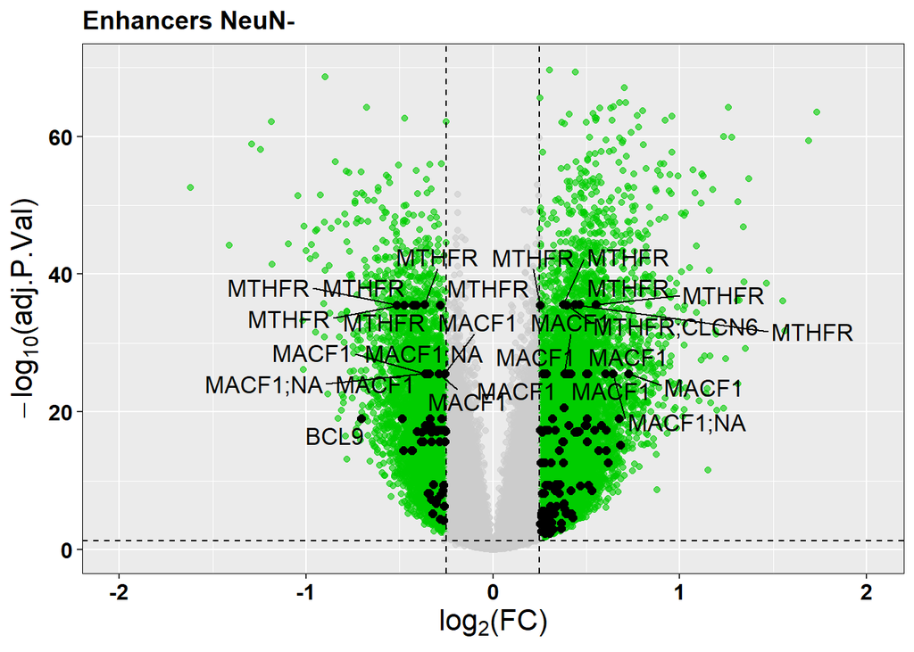

```r
ggsave("C:/Users/gianl/Desktop/ETH/BiologyMsc/Spring Semester Material/BARGE/Project/data/DF_plot_enh_Neupos.png",
       plot = plot1,
       width = 11,
       height = 8,
       dpi = 150)
# NeuN- Volcano Plot

res_enh_neg$significant <- res_enh_neg$adj.P.Val < pval_thresh & abs(res_enh_neg$logFC) > logFC_thresh

res_enh_neg$scz_gene <- sapply(res_enh_neg$gene, function(x){
  if (is.na(x)) return(FALSE)
  any(strsplit(x, ";")[[1]] %in% candidate_SCZ_genes)
})

res_enh_neg$plot_col <- ifelse(!res_enh_neg$significant, "not_significant",
                           ifelse(res_enh_neg$scz_gene, "scz_gene", "significant"))

res_enh_neg$plot_col <- factor(res_enh_neg$plot_col, levels = c("not_significant", "significant", "scz_gene"))

base_points_neg <- subset(res_enh_neg, !(scz_gene & significant))
scz_points_neg <- subset(res_enh_neg, scz_gene & significant)

plot2 <- ggplot()+
  geom_point(data = base_points_neg, aes(x = logFC, y = -log10(adj.P.Val), color = significant), alpha = 0.6)+
  geom_point(data = scz_points_neg, aes(x = logFC, y = -log10(adj.P.Val)), color = "black", size = 2)+
  scale_color_manual(values = c("TRUE" = "green3", "FALSE" = "grey80")
  )+
  geom_text_repel(
    data = scz_points_neg,
    aes(x = logFC, y =-log10(adj.P.Val), label = gene),
    size = 4.5,
    max.overlaps = 20)+
  geom_vline(xintercept = c(-logFC_thresh, logFC_thresh), linetype = "dashed")+
  geom_hline(yintercept = -log10(pval_thresh), linetype = "dashed")+
  xlim(-2, 2)+
  ylim(0,70)+
  theme(legend.position = "none")+
  labs(
    title = "Enhancers NeuN-",
    x = expression(log[2]*"(FC)"),
    y = expression(-log[10]*"(adj.P.Val)")
    )+
  theme(
    plot.title = element_text(size=14, face= "bold", colour= "black" ),
    axis.title.x = element_text(size=16, face="bold", colour = "black"),
    axis.title.y = element_text(size=16, face="bold", colour = "black"),
    axis.text.x = element_text(size=12, face="bold", colour = "black"),
    axis.text.y = element_text(size=12, face="bold", colour = "black"), # bold
    strip.text.x = element_text(size = 10, face="bold", colour = "black" ),
    strip.text.y = element_text(size = 10, face="bold", colour = "black"),
    panel.border = element_rect(colour = "black", fill=NA, size=0.3)
  )


print(plot2)
```

```r
ggsave("C:/Users/gianl/Desktop/ETH/BiologyMsc/Spring Semester Material/BARGE/Project/data/DF_plot_enh_NeuNneg.png",
       plot = plot2,
       width = 11,
       height = 8,
       dpi = 150)
```

## Barplot

```r
suppressPackageStartupMessages({
  library(ggplot2)
})
```

```r
# Import DFs of differential analysis

res_pro_pos <- readRDS("DF_DA_pro_NeuN+.rds")
res_pro_neg <- readRDS("DF_DA_pro_NeuN-.rds")

res_enh_pos <- readRDS("DF_DA_enh_NeuN+.rds")
res_enh_neg <- readRDS("DF_DA_enh_NeuN-.rds")
```

```r
# Select Differential Promoters/Enhancers
# authors used an FDR, preset as significance metric in limma, of 0.05.

sig_threshold <- 0.05

sig_pro_pos <- res_pro_pos[res_pro_pos$adj.P.Val < sig_threshold, ]
sig_pro_neg <- res_pro_neg[res_pro_neg$adj.P.Val < sig_threshold, ]

sig_enh_pos <- res_enh_pos[res_enh_pos$adj.P.Val < sig_threshold, ]
sig_enh_neg <- res_enh_neg[res_enh_neg$adj.P.Val < sig_threshold, ]

# dataframe with counts for each group

df_sig_elements <- data.frame(
  Category = rep(c("Enhancers", "Promoters"), each = 2),
  CellType = rep(c("NeuN+", "NeuN-"), 2),
  Count = c(
    nrow(sig_enh_pos),
    nrow(sig_enh_neg),
    nrow(sig_pro_pos),
    nrow(sig_pro_neg)
  )
)
```

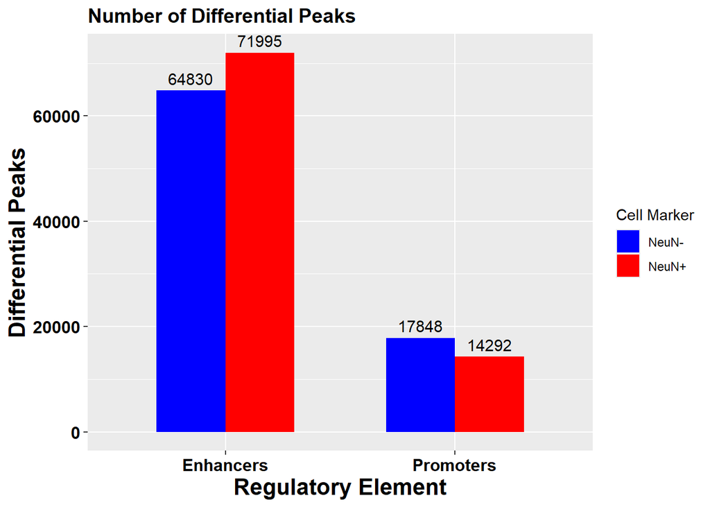

```r
# barplot

barplot <- ggplot(df_sig_elements, aes(x = Category, y = Count, fill = CellType))+
  geom_bar(stat = "identity", position = position_dodge(width = 0.6), width = 0.6)+
  geom_text(aes(label = Count),
            position = position_dodge(width = 0.6),
            vjust = -0.5, size = 4)+
  scale_fill_manual(values = c("NeuN-" = "blue","NeuN+" = "red"))+
  labs(
    title = "Number of Differential Peaks",
    x = "Regulatory Element",
    y = "Differential Peaks",
    fill = "Cell Marker"
  )+
   theme(
    plot.title = element_text(size=14, face= "bold", colour= "black" ),
    axis.title.x = element_text(size=16, face="bold", colour = "black"),
    axis.title.y = element_text(size=16, face="bold", colour = "black"),
    axis.text.x = element_text(size=12, face="bold", colour = "black"),
    axis.text.y = element_text(size=12, face="bold", colour = "black"), # bold
    strip.text.x = element_text(size = 10, face="bold", colour = "black" ),
    strip.text.y = element_text(size = 10, face="bold", colour = "black"),
  )

print(barplot)
```

```r
ggsave("C:/Users/gianl/Desktop/ETH/BiologyMsc/Spring Semester Material/BARGE/Project/data/barplot_DF.png",
       plot = barplot,
       width = 10,
       height = 10,
       dpi = 150
       )
```

## Visualising Tracks

```r
suppressPackageStartupMessages({
  library(epiwraps)
  library(GenomicRanges)
  library(ggplot2)
})
```

```r
# define region
region <- GRanges("chr1", IRanges(start=68000000, end=68100000))

base_path <- "C:/Users/gianl/Desktop/ETH/BiologyMsc/Spring Semester Material/BARGE/Project/data/GSE174407_RAW"

tracks <- list(
  H3K4me3_NeuNpos_untreated = file.path(base_path, "GSM5296610_SCZ_1_untreated_NeuN+_H3K4me3_R1.bw"),
  H3K4me3_NeuNpos_treated   = file.path(base_path, "GSM5296657_SCZ_16_treated_NeuN+_H3K4me3_R1.bw")
)

# Plot signal tracks

png("track_plot.png", width = 1200, height = 800)
p <- epiwraps::plotSignalTracks(
  files = tracks,
  region = region,
  return_plot = TRUE
)
dev.off()
```